# Modelling in Conservation Biology

## 4.4 Rhino 4. Multiple simulations - PVA and the concept of quasi-extinction

Now we will run our model including demographic variability and environmental noise over many simulations. This is the heart of PVA in that it allows us to quantify probabilities of risk given the results of many simulations. By calculating the probability of quasi-extinction for a given threshold, we can define the risk of extinction according to the IUCN risk categories (Mace and Lande 1991). First we can run 100 simulations and save the population trajectories in a new object `N`. Instead of a one-dimensional vector, `N` is now a matrix where columns will be the results of each simulation. The script nests the **Rhino 3** model into a second loop for each simulation run `j`.

```r
title="Rhino 4. Mult. sims of demogr. var. + env. noise"
runs = 100
years = 1986:2035
# empty matrix for population size at t,
# each column is filled by a run
N = matrix(NA, nrow=length(years), ncol=runs)
N[1,] = 35  # 35 female individuals in 1986
b = 0.14
d = 0.08
cvar = 0.1
sd_b = cvar*b
sd_d = cvar*d

# run the model, loop for each run
for(j in 1:runs){
    #loop for each year
    for (t in 2:length(N[,j])){
        Pb = runif(N[t-1,j],min=0,max=1)
        Pd = runif(N[t-1,j],min=0,max=1)
        env = rnorm(1,mean=0,sd=1)
        bt=b + sd_b*env
        dt=d - sd_d*env
        births = length(which(Pb < bt))
        deaths = length(which(Pd < dt))
        N[t,j] = N[t-1,j] + births - deaths
        if(N[t,j] < 0){N[t,j] = 0}
    }
}
```

**PVA plot function**

Here, I have created a function that will plot the results of our multi-simulation. The function’s input is in the first line and includes the name of the matrix object that holds the population size vectors as columns (in our case, `N`), an alternative vector of time values (in our case `years`), a defined quasi-extinction threshold (default = 20), and alternative label inputs for the x-axis and title.

```r
pva.plot<-function(N, time=1:nrow(N), quasi.ext=20, xlab="time", title="Title"){
    #x11(height=5, width=10)  #opens a blank graphics device
    op <- par(mfrow=c(1,2)) #divides the device into 1 row and 1 col

    #first plot
    plot(time, N[,1], type="n", ylim=c(0,max(N)), xaxs="i",
      yaxs="i", main=title, xlab=xlab, ylab="Population size")
    polygon(c(time, rev(time)), y=c(rep(quasi.ext, length(time)),
      rep(0, length(time))), col=rgb(1,0.5,0.5), border=NA)
    for (j in 1:ncol(N)){
        lines(time, N[,j], col=j)
    }

    # stats across runs, uses the "apply" function: apply(X, MARGIN, FUN, ...)
    MEAN = apply(N, 1, mean)
    SD = apply(N, 1, sd)
    UPPER = MEAN + SD
    LOWER = MEAN - SD
    SE = SD/sqrt(ncol(N))
    CI95 = cbind(MEAN-1.96*SE, MEAN+1.96*SE)
    # add region showing the std. dev range(grey) and conf. int.(blue)
    polygon(c(time, rev(time)), y=c(LOWER, rev(UPPER)),
      col=rgb(0.5,0.5,0.5,0.5), border=NA)
    polygon(c(time, rev(time)), y=c(CI95[,1], rev(CI95[,2])),
      col=rgb(0,0,1,0.5), border=NA)
    lines(time, MEAN, col=1, lwd=2, lty=1)
    box()

    #2nd plot - prob. of quasi-extinction
    QE = N < quasi.ext
    temp <- apply(QE, 2, which)
    first_QE <- NA*1:ncol(N)
    if(length(temp)>0){
        for(i in 1:length(first_QE)){
            if(length(temp[[i]])>0){first_QE[i] <- time[min(temp[[i]])]}
        }
    }
    histat<-hist(first_QE, plot=FALSE, breaks=pretty(time, 10))
    ncat = length(histat$breaks)-1
    t_ranges<-paste(histat$breaks[1:ncat], histat$breaks[2:(ncat+1)], sep="-")
    barplot(histat$counts/ncol(N), space=0, names.arg=t_ranges,
      ylim=c(0,1), las=2, cex.names=0.8, xlim=c(0,ncat),
      main="Probability of Quasi-Extinction")
    lines((1:ncat)-0.5,cumsum(histat$counts/ncol(N)),lty=2, type="b")
    text(ncat/2,y=0.5,paste("Cumulative","=",
      cumsum(histat$counts/ncol(N))[ncat]),font=2)
    box()
    par(op)
}
```

Plot the results of `N`:

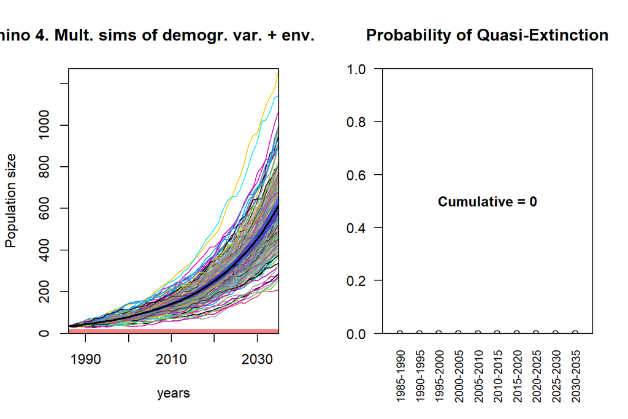

```r
pva.plot(N, time=years, xlab="years", title=title)
```

## 4.5 Rhino 5. Additional poaching mortality

One more bit of reality to the model – It is estimated that there is additional mortality from illegal poaching in the park at a rate of 2 % of the population per year on average. We will also incorporate this as a probability in the same way that we dealt with birth and death rates.

> **TASK:** Add additional lines of code to **Rhino 4** to incorporate the probability of poaching.

(Hint: as with `Pb` and `Pd`, you will need to create a vector of length `N[t-1]` with random uniformly-distributed numbers and use this to calculate the number of poached individuals. This will become an additional source of mortality in the calculation of `N[t]`)

**Spoiler Alert!!! :** Don’t look forward if you want to figure this out on your own.

## 4.6 Rhino 6. Management scenarios

Now we will run our full model including demographic variability, environmental noise and poaching. Two additional parameters have been added in order to simulate management strategies. The parameter cull_const is a constant representing the number of individuals that the park’s managers will cull each year. The second parameter, *ceiling*, defines a maximum population level whereby culling will occur for superior values.

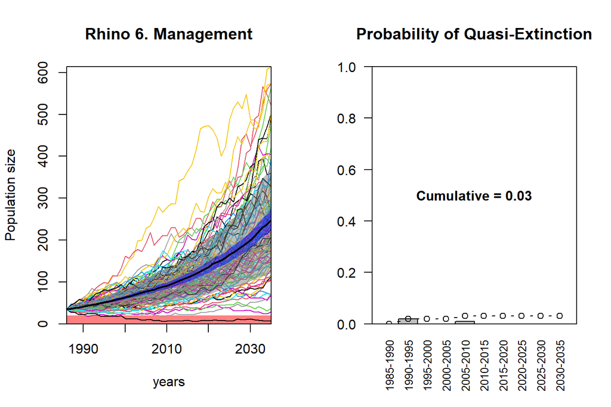

```r
title = "Rhino 6. Management"
runs = 100
years = 1986:2035
N=matrix(NA, nrow = length(years), ncol=runs)
N[1,] = 35
b = 0.14
d = 0.08
cvar = 0.3
sd_b=cvar*b
sd_d=cvar*d
poach_rate = 0.02
cull_const = 0  # constant removal of ind. at each t
ceiling = Inf  # ceiling, type "Inf" for no ceiling


#loop for each run
for(j in 1:runs){
  # loop for each year
    for (t in 2:length(N[,j])){
        Pb = runif(N[t-1,j],min=0,max=1)
        Pd = runif(N[t-1,j],min=0,max=1)
        # choose a random uniform distrib. number between
        # 0 and 1 for each ind.
        Pp = runif(N[t-1,j],min=0,max=1)
        env = rnorm(1,mean=0,sd=1)
        bt = b + sd_b*env
        dt = d - sd_d*env
        births = length(which(Pb < bt))
    deaths = length(which(Pd < dt | Pp < poach_rate))
    # adds the removal of culled ind.
    N[t,j] = N[t-1,j] + births - deaths - cull_const
    # if pop. size surpasses the ceiling, reduce pop. to ceiling
        if(N[t,j] > ceiling){ N[t,j] <- ceiling }
    if(N[t,j] < 0){N[t,j] = 0}
    }
}

pva.plot(N, time=years, xlab="years", title=title, quasi.ext=20)
```

> **TASK:** Using the full **Rhino 6** model, incorporate the various strategies above (differing cull rates, and ceilings) and compare the probability of quasi-extinction. Which strategy can both prevent population explosions while maintaining a low level of extinction risk (i.e. does not meet the criteria of “Vulnerable” - probability of extinction is at least 10 % within 100 years.)?

# 5 Matrix models

## 5.1 Age-structured matrix model

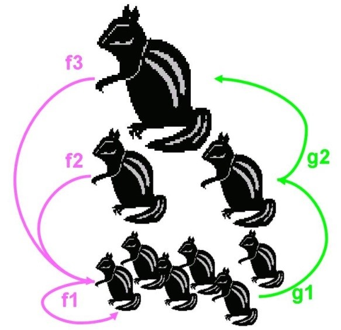

Chipmunk population consiting of 3 age classes. $f_x$ define fecundities and $g_x$ define survivorship or (i.e. transition) rates.

For the prediction of population growth, it is sometimes necessary to track the individuals within certain age or size classes. This is useful if demographic parameters such as fecundity or survivorship change during individual’s life and if this affects population’s structure.

Assume a population which can be structured into three different age classes $x = 1, 2, 3$. Then, the fecundity of the individuals could be labelled as $f_x$, and the probability that the individuals survive their age class $g_x$. Let, furthermore, $n_{x,t}$ denote the number of individuals within each age class at time $t$. We can now calculate the number of individuals in the next time step as:

$$\begin{aligned}
n_{t+1,1} = f_1 \times n_{t,1} + f_2 \times n_{t,2} + f_3 \times
n_{t,3} \\
n_{t+1,2}=g_1 \times n_{t,1} \\
n_{t+1,3}=g_2 \times n_{t,2}
\end{aligned}$$

This model makes two assumptions:

1. All age classes have the same time increment.
2. There are no survivors after the last age class.

The defined age classes must be, therefore, large enough to capture the entire life span of the individuals.

To condense the form of these equations we can use matrix arithmetic:

$$\mathrm{L} =
\begin{bmatrix}
f_1 & f_2 & f_3 \\
g_1 & 0 & 0 \\
0 & g_2 & 0
\end{bmatrix}$$
Includes all fecundities $f_x$ in the first row and the transition rates $g_x$ between the age classes in the “sub-diagonal”. Since P.H. Leslie introduced this notation into the studies of population growth, it is called *LESLIE*-matrix.

$$\mathrm{N}_t = \begin{bmatrix}
n_{t,1} & n_{t,2} & n_{t,3}
\end{bmatrix}$$

Each element of this vector marks the individuals within an age class at time $t$.

> **TASK:** Use the following information to create an age-structured population model for the chipmunk population.

Assume a population that can be described by the following matrix:

$$\mathrm{L} =
\begin{bmatrix}
0.5 & 1 & 0.75 \\
0.6666 & 0 & 0 \\
0 & 0.3333 & 0
\end{bmatrix}$$

## 5.2 Iterative projection of a matrix model

Now we will learn to iterated the population over time. In order to calculate the number of individuals in each age class at time t+1, the vector of population numbers by age is multiplied by the matrix, $\mathrm{N}_{t+1} = \mathrm{L} \times \mathrm{N}_t$. In *R* we use the notation `%*%` to denote a matrix multiplication.

```r
# To multiply matrices, we use the %*% operator
N = c(2, 0, 0) # pop at t
L %*% N # pop at t+1
```

In the following example, the initial population (`N0`) is initialized by two individuals in the first age class:

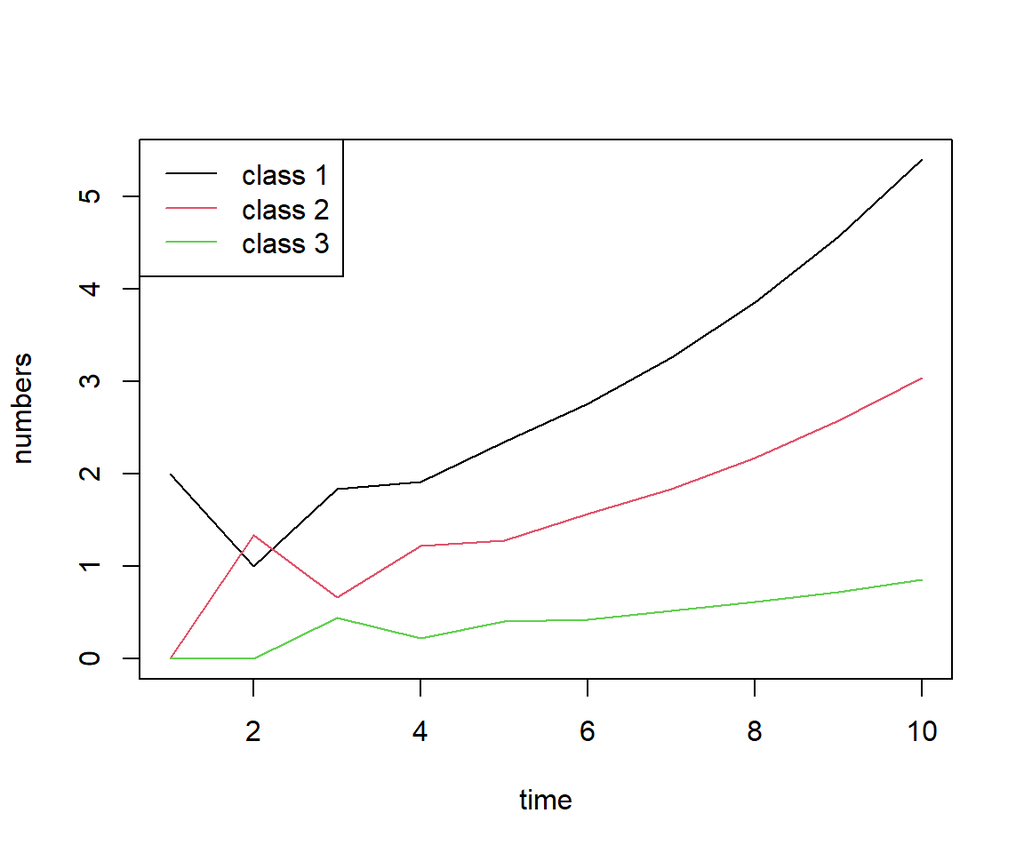

```r
time <- 1:10
N0 <- c(2,0,0)

POP <- matrix(NaN, nrow=length(time), ncol=length(N0))
POP[1,] <- N0
for (i in 2:length(time)){
    POP[i,] <- L %*% POP[i-1,]
}

plot(time,POP[,1], type="l", ylim=range(POP), ylab="numbers", xlab="time")
for (i in 2:length(POP[1,])){
    lines(seq(time),POP[,i],col=i)
}

legend("topleft", c(paste("class",(1:length(N0)))), lwd=1, col=c(1:length(N0)))
```

## 5.3 Direct evaluation of a matrix model

Using a matrix for calculating age/class dynamics has an advantage in terms of calculation speed. Furthermore, for a square matrix, the matrix governs the behavior of solutions to the corresponding system of linear equations. An *Eigen decomposition* of this matrix can reveal several aspects of the population (at equilibrium). The following sections outline how to extract the following information from a matrix model:

1. Rate of population growth
2. Stable age/stage distribution
3. Reproductive value
4. Parameter sensitivity and elasticity

### 5.3.1 Population growth rate

**Eigenvalues** provide insight into the geometry of the associated linear transformation. Specifically, the dominant, or largest, eigenvalue is related to the population growth rate at equilibrium. In practical terms, the dominant (1st) eigenvalue ($\lambda$) of the matrix should give roughly the same value as the rate of change for the whole population as it reaches equilibrium. In the above iteration of the population, the Leslie matrix, $\mathrm{L}$, acts as a coefficient of change for all classes simultaneously, $\mathrm{N}_{t+1}=\mathrm{L} \times \mathrm{N}_t$. The value of $\lambda$ simplifies this rate of change to a single value, such as one would use for a simulating a population without classes: $n_{t+1}=\lambda \times n_t$. In order to derive $\lambda$, we first conduct an Eigen decomposition; The function returns a list containing eigenvalues (`x$values`) and eigenvectors (`x$vectors`). The value of $\lambda$ may not seem obvious given that it is a complex number containing a “real” and “imaginary” part. We are only concerned with the real part, which you can return with the `Re` function:

```r
x <- eigen(L)
x
```

```
## eigen() decomposition
## $values
## [1]  1.1827318+0.0000000i -0.3413659+0.1560701i -0.3413659-0.1560701i
##
## $vectors
##              [,1]                  [,2]                  [,3]
## [1,] 0.8629405+0i -0.3529165+0.1613509i -0.3529165-0.1613509i
## [2,] 0.4863623+0i  0.6891554+0.0000000i  0.6891554+0.0000000i
## [3,] 0.1370595+0i -0.5565407-0.2544465i -0.5565407+0.2544465i
```

```r
Re(x$values)[1] # dominant (1st) eigenvalue
```

```
## [1] 1.182732
```

The population doubling time can also be calculated directly:

```r
# Doubling time
lambda <- Re(x$values)[1]
log(2)/log(lambda)
```

```
## [1] 4.130134
```

The dominant eigenvalue is more like a percent increase [%] in its interpretation, such that a value of 1.1 would mean that a population is increasing at 10% per time unit ((1.1 – 1.0) * 100% = 10%). A value <1.0 means that the population is decreasing (*e.g.* ((0.9 - 1.0) * 100% = -10%).

> **TASK:** Compare $\lambda$ to that of the rate of population change between the last two iterations (*i.e.* t=9 vs. t=10). As a first step, `rowSums(POP)` will give you the sum population size by summing all age classes at each time step (row).

### 5.3.2 Stable population distribution

The stable population distribution is specified by the 1st **eigenvector**. The proportion of each element of the vector sum equals the corresponding class proportions when the population is at equilibrium:

```r
Re(x$vectors[,1]/sum(x$vectors[,1]))
```

```
## [1] 0.58057213 0.32721653 0.09221133
```

### 5.3.3 Reproductive value

The “reproductive value” is the value of a given age-class or stage as a seed for population growth (newborn or first age class reproductive value = 1.0 by definition). It represents the expected number of offspring per individual over the remaining lifetime. It is calculated from the **left eigenvector**, which can be obtained by using the `eigen` function on the transpose (`t()`) of the matrix:

```r
x <- eigen(t(L))
Re(1/x$vectors[1,1] * x$vectors[,1])
```

```
## [1] 1.0000000 1.0242001 0.6341252
```

### 5.3.4 Parameter sensitivity and elasticity

Matrix models can easily tell us about the transitions in the life cycle to which the population growth rate ($\lambda$) is **sensitive** or **elastic** to changes. This can be important information for conservation efforts; For example, if the trajectory of the population growth rate is sensitive to small changes in a particular parameter, then we will need to make very accurate measurements of its value. On the other hand, insensitive parameters suggest places where one may not want not invest too much conservation resources.

**Sensitivity** ($s$) is the effect of an *absolute change* in a vital rate on $\lambda$. For example, if we change first-year survival by 0.01, how much will that affect the population growth rate? *e.g.*,

$$s_{ij}=\frac{\delta \lambda}{\delta p_{ij}}$$

where $\delta \lambda = \lambda_{new}-\lambda_{old}$ and $\delta p_{ij}=p_{ij_{new}} - p_{ij_{old}}$.

**Elasticity** ($e$) is the effect of a proportional change on $\lambda$. For example, if we change first-year survival by 1%, how much will that affect population growth? *e.g.*,

$$e_{ij} =
\Big(\frac{\delta \lambda}{\delta p_{ij}}\Big)
\Big(\frac{p_{ij}}{\lambda}\Big) =
\frac{\delta \log(\lambda)}{\delta \log(p_{ij})}$$

The following script calculates both measures given a change in value to a single parameter of a matrix:

```r
M.old <- L # copy matrix
M.new <- M.old
idx <- 2 # matrix element to change
noise <- 1e-6 # small perturbation value
p.old <- M.old[idx]
p.new <- M.old[idx] + noise
M.new[idx] <- p.new # replace new value in new Usher matrix
l.old <- Re(eigen(M.old)$val[1])
l.new <- Re(eigen(M.new)$val[1])

# sensitivity
(l.new-l.old) / (p.new-p.old)
```

```
## [1] 0.6103813
```

```r
 # elasticity (proportional sensitivity)
((l.new-l.old) / (p.new-p.old)) * (p.old/l.old)
```

```
## [1] 0.3440173
```

```r
# alternate calc. of elasticity
(log(l.new)-log(l.old)) / (log(p.new)-log(p.old))
```

```
## [1] 0.3440175
```

> **TASK:** Calculate the elasticity for each of the fecundity values in the age-structured Leslie matrix from above. Then, compare to their respective reproductive values.

> **EXTRA TASK:** Create functions for the following matrix outputs:
- Rate of population growth & stable distribution
- Reproductive value
- Parameter sensitivity and elasticity

## 5.4 Case Study: Whitetip reef shark (Triaenodom obesus)

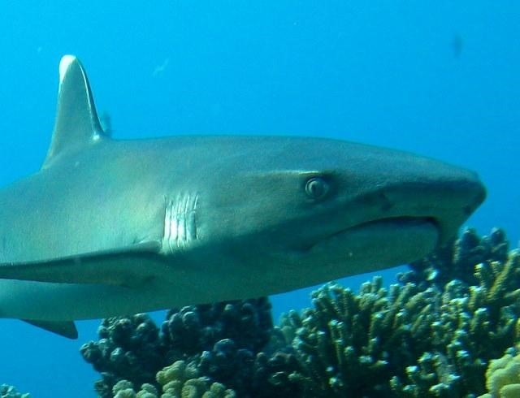

Whitetip reef shark (Triaenodom obesus). Credit: Pascal Irz, FishBase.

In the following example, we will use a Leslie matrix model to investigate strategies for improving the population growth rate of the Whitetip reef shark (*Triaenodon obesus*). *T obesus* is listed as “Near threatened” on the IUCN Red List classification, with main threats coming from line and net trawl fisheries operating in shallow reef areas. Population growth rates are slow due to its relatively slow growth (K = 0.25) and viviparous reproduction and low fecundity (1-5 pups, gestation 12 months). The following Leslie matrix model derives life history information from FishBase [link](http://www.fishbase.org/summary/Triaenodon-obesus.html):

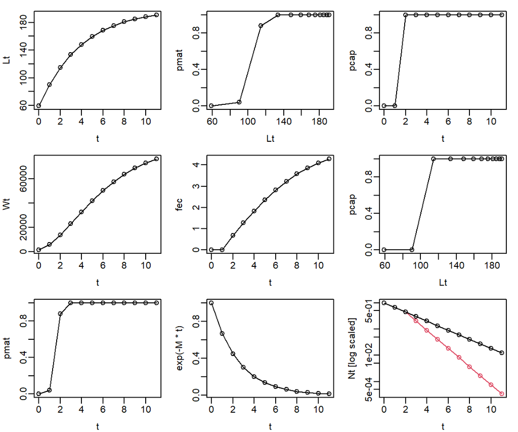

```r
# setup for plots
op <- par(mfcol = c(3,3), mgp = c(2,0.5,0), mar = c(3,3,1,1))

### Growth
# Length - von Bertelanffy growth function (VGBF):
# Lt <- Linf * (1-exp(-k*(t-t0)))
K <- 0.25
Linf <- 200
# t0 is adjusted so that newborn pup length (L0)
# is ca. 60 cm [ L0 <- Linf *(1-exp(-K*(0-t0)))) ]
t0 <- -1.4
# Max. age "rule of thumb" (Taylor CC, 1958.
# Cod growth and temperature.
# Journal du Conseil 23: 366-370.)
Amax <- round(log(-(0.95*Linf)/Linf + 1) / -K + t0)
t <- seq(0, Amax)
Lt <- Linf *(1-exp(-K*(t-t0)))
plot(t, Lt, t="o")

# Weight: Wt <- a*Lt^b
a <- 0.0018
b <- 3.344
Wt <- a*Lt^b
plot(t, Wt, t="o")


### Maturity
Lmat50 <- 105
Lmat25 <- Lmat50 * 0.95
Lmat75 <- Lmat50 * 1.05
wmat <- Lmat75 - Lmat25
pmat <- 1 / (1 + exp(
  -(Lt - Lmat50) / (wmat/(log(0.75/(1-0.75)) -
    log(0.25/(1-0.25)) ))
))
plot(t, pmat, t="o")
plot(Lt, pmat, t="o")


### Fecundity
# infinite weight
Winf <- a*Linf^b
# maximum of 5 pups and number is proportional to weight
npups <- 5 * Wt / Winf
fec <- npups * pmat
plot(t, fec, t="o")

### Mortality
# Natural Mortality
# after Jensen (1996):
# M <- 1.6 * K
# after Pauly (1980):
M <- round(10^(-0.0066 - 0.279*log10(Linf) + 0.6543*log10(K) + 0.4634*log10(25)),2)
plot(t, exp(-M*t), t="o")

# Probability of capture
Lcap <- 100 # Length of 1st capture
pcap <- Lt >= Lcap # "knife edge" selection when Lt>=Lcap
plot(t, pcap, t="o")
plot(Lt, pcap, t="o")

# Fishing mortality
F <- M
Ft <- F * pcap

# Total mortality
Zt <- M + Ft
Nt <- NaN*t; Nt[1] <- 1
for(i in seq(t)[-1]){
    Nt[i] <- Nt[i-1]*exp(-Zt[i-1])
}
plot(t, Nt, t="o", log="y", col=2, ylab = "Nt [log scaled]")
lines(t, Nt[1]*exp(-M*t), t="o")
```

```r
par(op)
```

Here we use the data to construct a Leslie matrix:

```r
### Leslie matrix construction
L <- matrix(0, length(t), length(t))
# 1st row of fecundity values (fx's)
L[1,] <- fec
# position of subdiagonal
subdiag <- which(row(L) == col(L) + 1)
# subdiagonal substitution of survivorship values (gx's)
L[subdiag] <- exp(-Zt)[-length(Zt)]

# Resulting Leslie matrix
round(L,2)
```

```
##       [,1] [,2] [,3] [,4] [,5] [,6] [,7] [,8] [,9] [,10] [,11] [,12]
##  [1,] 0.00 0.02 0.68 1.29 1.83 2.35 2.82 3.23 3.58  3.86  4.10  4.29
##  [2,] 0.67 0.00 0.00 0.00 0.00 0.00 0.00 0.00 0.00  0.00  0.00  0.00
##  [3,] 0.00 0.67 0.00 0.00 0.00 0.00 0.00 0.00 0.00  0.00  0.00  0.00
##  [4,] 0.00 0.00 0.45 0.00 0.00 0.00 0.00 0.00 0.00  0.00  0.00  0.00
##  [5,] 0.00 0.00 0.00 0.45 0.00 0.00 0.00 0.00 0.00  0.00  0.00  0.00
##  [6,] 0.00 0.00 0.00 0.00 0.45 0.00 0.00 0.00 0.00  0.00  0.00  0.00
##  [7,] 0.00 0.00 0.00 0.00 0.00 0.45 0.00 0.00 0.00  0.00  0.00  0.00
##  [8,] 0.00 0.00 0.00 0.00 0.00 0.00 0.45 0.00 0.00  0.00  0.00  0.00
##  [9,] 0.00 0.00 0.00 0.00 0.00 0.00 0.00 0.45 0.00  0.00  0.00  0.00
## [10,] 0.00 0.00 0.00 0.00 0.00 0.00 0.00 0.00 0.45  0.00  0.00  0.00
## [11,] 0.00 0.00 0.00 0.00 0.00 0.00 0.00 0.00 0.00  0.45  0.00  0.00
## [12,] 0.00 0.00 0.00 0.00 0.00 0.00 0.00 0.00 0.00  0.00  0.45  0.00
```

```r
# population growth rate
round(Re(eigen(L)$values[1]), 3)
```

```
## [1] 0.987
```

```r
# population structure at equilibrium
round(Re(eigen(L)$vectors[,1]) / sum(Re(eigen(L)$vectors[,1])), 3)
```

```
##  [1] 0.396 0.269 0.183 0.083 0.038 0.017 0.008 0.004 0.002 0.001 0.000 0.000
```

> **TASK:** Explore the effect of different rates of fishing mortality (F) and length of 1st capture (Lcap) on the growth rate of the population. The following object, grd, should get you started. It gives all possible combinations of F and Lcap across a given range of values, and includes an empty variable, called “lambda” (`grd$lambda`), for storing the resulting rate of population growth:

```r
Fs <- seq(0, 1, length.out=11)
Lcaps <- seq(0, Linf*0.9, length.out=10)
grd <- expand.grid(F = Fs, Lcap = Lcaps, lambda = NaN)
head(grd, n=20)
```

|  | F | Lcap | lambda |
| --- | --- | --- | --- |
| 1 | 0.0 | 0 | NaN |
| 2 | 0.1 | 0 | NaN |
| 3 | 0.2 | 0 | NaN |
| 4 | 0.3 | 0 | NaN |
| 5 | 0.4 | 0 | NaN |
| 6 | 0.5 | 0 | NaN |
| 7 | 0.6 | 0 | NaN |
| 8 | 0.7 | 0 | NaN |
| 9 | 0.8 | 0 | NaN |
| 10 | 0.9 | 0 | NaN |

[output cut: 10 more lines]

Using a loop, cycle through each row of `grd`, and use the various combinations of F and Lcap to recalculate the Leslie matrix. Then, calculate the population growth rate and save the results in the corresponding row of `grd$lambda`.

The following function will plot the results:

```r
plot.growth <- function(grd){
    pal=colorRampPalette(c(rgb(1,0.3,0.3), rgb(0.9,0.9,0.9)))
    mat <- matrix(grd$lambda, nrow=length(unique(grd$F)), ncol=length(unique(grd$Lcap)))
    image(x=unique(grd$F), y=unique(grd$Lcap), z=mat, col=pal(50), xlab="F", ylab="Lcap")
    suppressWarnings(rug(Lt, side=2, col=4))
    box()
    abline(h=Lmat50, col=4, lty=2, lwd=2)
    contour(x=unique(grd$F), y=unique(grd$Lcap), z=mat, add=TRUE, col=1)
    contour(x=unique(grd$F), y=unique(grd$Lcap), z=mat, levels=1, lwd=2, add=TRUE, col=1)
    mtext("Population growth rate", side=3, line=0.25, cex=1.2)
}

# plot.growth(grd)
```

When done correctly, you should be able to produce a figure like the one below using the `plot.growth` function:

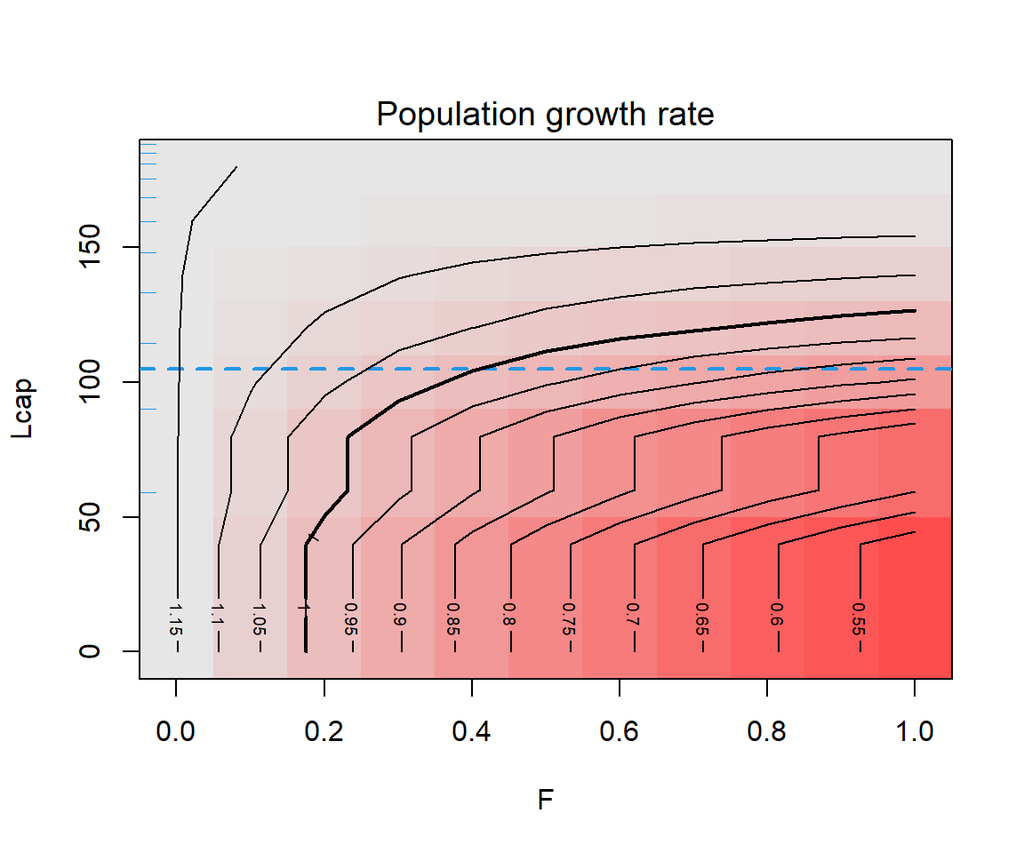

Example of the influence of F and Lcap on population growth rate (output from plot.growth function). Blue dashed line shows the length of maturity (Lmat50), and the thick contour isoline delineates where population growth is stable (i.e. equaling 1.0).

> **TASK:** Discuss how the exploration above differs from that of a Yield per Recruit (Y/R) model. The figure below (left) shows a Yield Isopleth Diagram (YID)(Beverton and Holt 1957), with Y/R as a function of fishing mortality (F) and length of 1st capture (Lcap). Escapement Spawning Stock (ESS) is the biomass of mature individuals (presented as a relative value below to that of the virgin, unfished stock). Fraction Megaspawners (MS) refers to the fraction of fish that are at least 10% larger than the size at which an unfished stock (F=0) maximizes cohort biomass (Lopt):

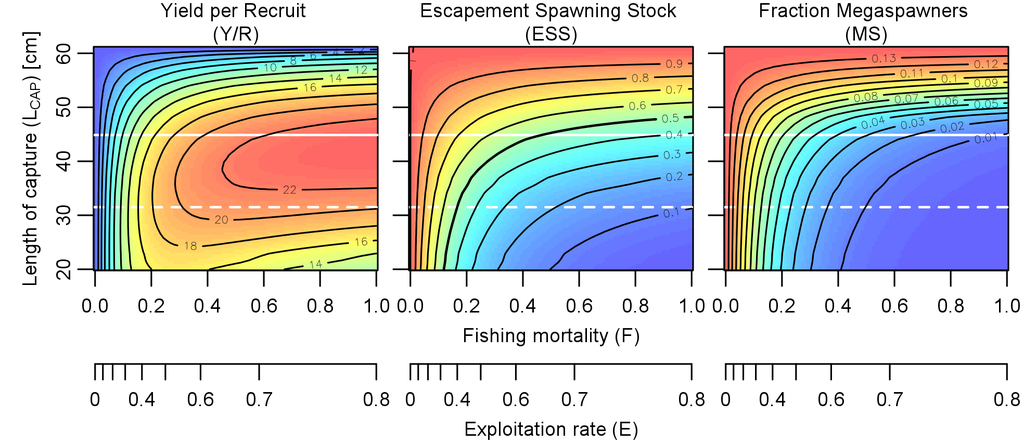

*Clarias gariepinus* – yield and spawning stock explorations under conditions of trawl selection (assuming knife-edge selection). yield per recruit (YPR) (left), escapement spawning biomass (ESS) relative to the unfished stock (middle), and fraction of population classified as mega-spawners (MS)(right) as a function of fishing mortality (F) and length at first capture assuming trawl selection. Body lengths of maximum cohort biomass (Lopt, solid white line) and maturity (L50, dashed white line) are shown for reference (from Wolff, Taylor, and Tesfaye 2015).

## 5.5 Stage-structured matrix model

In last decades different matrix-types have been used to analyze size- or stage-structured populations. In this model, it is assumed that not all individuals of a certain size/stage class leave the class after a defined time span; rather, there is a probability of remaining in the same class for the given time increment. By using size/stage classes, one might be better able to define an individual’s performance (fecundity, survivorship, etc.) than according to age. As a result, the time spent in each class may be uneven. To handle this model, **Usher** or **Lefkovich** - matrices are suitable:

$$\mathrm{U} =
\begin{bmatrix}
p_1 & f_2 & f_3 & f_4 \\
g_1 & p_2 & 0 & 0 \\
0 & g_2 & p_3 & 0 \\
0 & 0 & g_3 & p_4
\end{bmatrix}$$

This is an Usher matrix where the diagonal elements $p_x$ characterize the proportion of individuals in each stage who remain in that stage. The sub-diagonal elements $g_x$ are, again, the transition rates, i.e. the proportion that graduates to the next stage per time step. Except for the first element, the top row specifies fecundities, $f_x$.

$$\mathrm{N}_t = \begin{bmatrix}
n_{t,1} & n_{t,2} & n_{t,3} & n_{t,4}
\end{bmatrix}$$

Again, a vector is used to hold the number of individuals within a size/stage class at time $t$.

## 5.6 Case Study: Loggerhead turtle stage-based matrix model

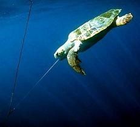

A loggerhead caught by a longline. Credit: scienceblogs.com

The case of the Loggerhead sea turtle (Caretta caretta), presented by Crouse et al. (1987), will be used as an example of a stage-based Usher matrix model. The Loggerhead population has been divided into 7 life history stages.

From Crouse, Crowder, and Caswell (1987): Stage-based life table for loggerhead sea turtles based on data in Frazer (1983a). These values assume a population declining at $ca.~ 3 \% ~ year^{-1}$.

| Stage number | Class | Size* (cm) | Approximate ages (yr) | Annual survivorship | Fecundity (no. eggs yr-1) |
| --- | --- | --- | --- | --- | --- |
| 1 | Eggs, hatchlings | <10 | <1 | 0.6747 | 0 |
| 2 | Small juveniles | 10.1-58.0 | 1-7 | 0.7857 | 0 |
| 3 | Large juveniles | 58.1-80.0 | 8-15 | 0.6758 | 0 |
| 4 | Subadults | 80.1-87.0 | 16-21 | 0.7425 | 0 |
| 5 | Novice breeders | >87 | 22 | 0.8091 | 127 |
| 6 | 1st-yr remigrants | >87 | 23 | 0.8091 | 4 |
| 7 | Mature breeders | >87 | 24-54 | 0.8091 | 80 |

$*$ Straight carapace length

Using this original data, the authors were able to adapt the stage-based life-history data to an Usher matrix. Fecundity data (fx) can be used directly, but the annual survival rates needed to be converted to stage-based probabilities of advancement. For each class $i$, yearly survival rates, $p_i$, and years spent in the class, $d_i$, were used to calculate the transition rates: 1) probability to stay within the class, $P_i$, and 2) probability to advance to the next class, $G_i$:

```r
# Deriving probabilities of staying and advancing
# from Eqs. 1 & 2 in Crouse et al. (1987)
# ex. Stage 2. small juveniles
p_i <- 0.7857 # yearly survival rate
d_i <- 7 # years in class
P_i <- ((1-p_i^(d_i-1))/(1-p_i^(d_i)))*p_i #(prob. to stay)
G_i <- ((p_i^d_i)*(1-p_i))/(1-p_i^d_i) # (prob. to advance)
P_i; G_i

# ex. Stage 3. large juveniles
p_i <- 0.6758 # yearly survival rate
d_i <- 8 # years in class
P_i <- ((1-p_i^(d_i-1))/(1-p_i^(d_i)))*p_i #(prob. to stay)
G_i <- ((p_i^d_i)*(1-p_i))/(1-p_i^d_i) # (prob. to advance)
P_i; G_i
```

The resulting Usher matrix structure:

$$\mathrm{U} =
\begin{bmatrix}
p_1 & f_2 & f_3 & f_4 & f_5 & f_6 & f_7 \\
g_1 & p_2 & 0 & 0 & 0 & 0 & 0 \\
0 & g_2 & p_3 & 0 & 0 & 0 & 0 \\
0 & 0 & g_3 & p_4 & 0 & 0 & 0 \\
0 & 0 & 0 & g_4 & p_5 & 0 & 0 \\
0 & 0 & 0 & 0 & g_5 & p_6 & 0 \\
0 & 0 & 0 & 0 & 0 & g_6 & p_7 \\
\end{bmatrix}$$

The resulting Usher matrix contained the following values:

Stage-class population matrix for loggerhead sea turtles based on the life table presented in Table 3 of Crouse, Crowder, and Caswell (1987).

|  | eggs_hatch | sm_juv | lg_juv | subadult | nov_breeder | 1st-yr_remigr | mat_breeder |
| --- | --- | --- | --- | --- | --- | --- | --- |
| eggs_hatch | 0.0000 | 0.0000 | 0.0000 | 0.0000 | 127.0000 | 4.0000 | 80.0000 |
| sm_juv | 0.6747 | 0.7370 | 0.0000 | 0.0000 | 0.0000 | 0.0000 | 0.0000 |
| lg_juv | 0.0000 | 0.0486 | 0.6610 | 0.0000 | 0.0000 | 0.0000 | 0.0000 |
| subadult | 0.0000 | 0.0000 | 0.0147 | 0.6907 | 0.0000 | 0.0000 | 0.0000 |
| nov_breeder | 0.0000 | 0.0000 | 0.0000 | 0.0518 | 0.0000 | 0.0000 | 0.0000 |
| 1st-yr_remigr | 0.0000 | 0.0000 | 0.0000 | 0.0000 | 0.8091 | 0.0000 | 0.0000 |
| mat_breeder | 0.0000 | 0.0000 | 0.0000 | 0.0000 | 0.0000 | 0.8091 | 0.8089 |

> **TASK:** 1. Create a matrix as seen above (Hint: you can adapt the previous model example by replacing the elements and dimensions of the matrix). 2. Using the starting population vector, `N0=c(100, 10, 5, 4, 3, 2, 1)`, run the model for 100 years to view the population stage trajectories. 3. Calculate the rate of population change and population structure at equilibrium?

You will notice that with these original parameters the population is decreasing. One pervasive problem in sea turtle conservation is the removal of eggs from nests (by man, feral dogs, pigs etc.). In many parts of the world, the protection of nesting beaches is a common strategy for conservation. Would this be a worthwhile strategy for this Loggerhead population?

> **TASK:** Calculate the new rate of population change under a scenario of complete nest protection - Although unrealistic, assume that all eggs/hatchlings (stage 1) survive to be small juveniles (stage 2).

> **TASK:** Explore the elasticity of transition values of the matrix ($p_x$, $g_x$) and the reproductive values ($f_x$) of each class. What do the results tell us about where conservation efforts should be focused?

# 6 Management Strategy Evaluation

Management Strategy Evaluation (**MSE**) is a simulation framework that allows for the comparison of the relative effectiveness for achieving management objectives of different combinations of data collection schemes, methods of analysis and subsequent processes leading to management actions (Punt et al. 2016). There are many “flavors” of MSE, but “best practices” dictate that the framework should be used to identify of management strategies that are robust to uncertainty rather than strategies that are optimal for a particular scenario.

MSE consists of two main processes that feedback to each other; 1. the “operating model” (**OM**), which is used to simulate the “true” system of resource dynamics, including both the fishery and the biological processes, and 2. the management strategy or procedure (**MP**), which is used to simulate the process of management, including data analysis and application of a decision process (e.g harvest control rule).

In the **OM**, management decisions are translated into action (e.g. Total Allowable Catch, TAC) within the implementation model. This is the first possible source of uncertainty, which can be in the form of a mismatch between advised management and implemented action. Once implemented, the OM simulated the interaction of the resource and the resource use (e.g. Biological and fishery model). Again uncertainty can enter in to this step through variability in many parameters and rates (e.g. selectivity, mortality rates), rather than holding these constant through time. Then is the Data generation step, which provides the observations that will be used by the MP. These can be e.g. catch data, scientific survey data, etc. Again, uncertainty can enter in here in many forms.

In the **MP**, data is analysed according to (in the best cases) the same method used to estimate the state of the resource (e.g. a particular stock assessment model). Uncertainty arises due to differences in the assessment model versus the OM, as well as poor estimation due to the underlying noise in the data. This perceived state of the resource forms the basis of management decisions, e.g. via a harvest control rule (HCR), which in turn feed back into the OM. The performance of a given MP can be evaluated using any criteria agreed upon. For example, ICES requires that a given MP is able to maintain a stock’s biomass above a given reference point, below which the stock’s productivity may be impaired. For example, the spawning stock biomass (SSB) associated with the last above-average recruitment ($B_{lim} = 107,000$). If a given HCR does not maintain the SSB above Blim with a probability of 95%, then it is not considered precautionary.

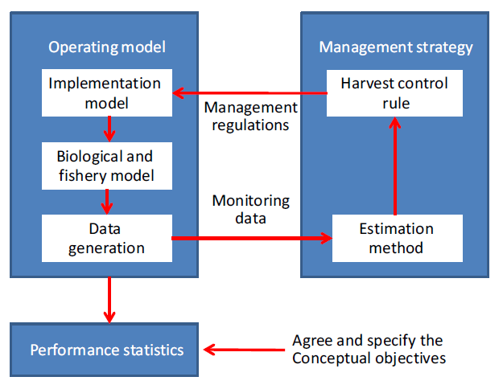

Conceptual overview of the management strategy evaluation modelling process (from Punt et al. 2016).

## 6.1 Case Study: A simple MSE

In the following case study, we will simulate a population using a simple logistic-type growth function with Allee effect. The example uses a simplified MP where there is not true assessment model applied, but simply an observed estimate of the population with error. Additional uncertainty is introduced via the implementation of the harvest control rule. Additional variation is introduced in the variation of $K$ an $r$.

### 6.1.1 Required functions

```r
# logistic growth function
logisticAllee <- function(r = NULL, K = NULL, a = 0, B = NULL){
  if(is.null(r) | is.null(K) | is.null(B)){stop("Must define 'r', 'K' and 'B'")}
  dBdt <- r*B*(1-(B/K))*((B-a)/K)
  B2 <- B + dBdt
  return(B2)
}

# harvest control rule function
hcr <- function(B, Btrig = 300, Ftarg = 0.1){
  Fadv <- ifelse(B < Btrig, 0 + (Ftarg/Btrig)*B, Ftarg)
  Y <- B * Fadv
  return(list(Fadv=Fadv, Y=Y))
}

# Management Strategy Evaluation function
mse <- function(
  K = 1000, # carrying capacity
  r = 0.2, # growth constant
  a = 0, # Allee effect term
  nyear = 1000, # number of years to simulate
  Btrig = 400, # hcr population size limit
  Ftarg = 0.13, # hcr target fishing mortality
  B1 = 500, # inital population size
  assess_err = 0.2,# assessment error (cv)
  imp_err = 0.1, # yield implimentation error (cv)
  r_var = 0.2, # variation in r (cv)
  K_var = 0.1 # variation in K (cv)
){
  # make empty results object
  df <- data.frame(
    Breal = seq(nyear)*NaN, Bobs = NaN, dBdt = NaN,
    Freal = NaN, Fadv = NaN,
    Yreal = NaN, Yadv = NaN)

  # intialize population
  df$Breal[1] <- B1

  # run MSE through all years
  for(i in seq(nyear)){
    ### Management Procedure (MP)
    df$Bobs[i] <- df$Breal[i] * rlnorm(1, sdlog = assess_err) # observe stock
    adv <- hcr(B = df$Bobs[i], Btrig = Btrig, Ftarg = Ftarg) # call to HCR
    df$Fadv[i] <- adv$Fadv # record F advice
    df$Yadv[i] <- adv$Y # record yield advice
    df$Yreal[i] <- df$Yadv[i] * rlnorm(1, sdlog = imp_err) # realized yield
    df$Freal[i] <- df$Yreal[i] / df$Breal[i] # realized F
    ### Operating Model (OM)
    B2 <- logisticAllee(B = df$Breal[i] - df$Yreal[i], # grow stock
      r = r * rlnorm(1, sdlog = r_var), K = K * rlnorm(1, sdlog = K_var),
      a = a)
    df$dBdt[i] <- B2-(df$Breal[i]-df$Yreal[i]) # record production
    if(i != nyear){ # record new pop state (if not last year)
      df$Breal[i+1] <- B2
    }
  }
  return(df)
}

# plot results of mse function
mseplot <- function(df,
  ptcol = adjustcolor(1,0.2), linecol = 4, pch = 16){
  op <- par(mfrow = c(2,2), mar = c(4,4,1,1), mgp = c(2,0.5,0))
  # plot 1
  plot(df$Bobs, t = "l", col = ptcol)
  lines(df$Breal, col = linecol, lty = 1)
  legend("top", legend = c("Bobs", "Breal"), ncol=2, bty = "n",
    lty=1, col = c(ptcol, linecol))
  # plot 2
  plot(dBdt ~ Breal, df, pch = pch, col = ptcol)
  fit <- lm(dBdt ~ -1 + poly(Breal, degree = 2, raw = TRUE), df)
  newdf <- data.frame(Breal=seq(0, max(df$Breal), len = 100))
  newdf$dBdt <- predict(fit, newdata = newdf)
  lines(dBdt ~ Breal, newdf, col = linecol, lty = 2)
  cs <- coef(fit)
  legend("bottom",
    legend = c(paste("Bmsy =", round(-cs[1]/(2*cs[2]))),
      paste("K =", round(-cs[1]/cs[2]))),
    bty = "n", ncol = 2)
  # plot 3
  plot(Breal ~ Bobs, df, log = "xy", pch = pch, col = ptcol)
  abline(0,1, lty = 2, col = linecol)
  # plot 4
  plot(Freal ~ Fadv, df, log = "xy", pch = pch, col = ptcol)
  abline(0,1, lty = 2, col = linecol)
  par(op)
}

# probability calculation function
pcalc <- function(B, Blim = 200){
  # annual probability of B < Blim
  annP <- apply(B, 1, function(x){mean(x < Blim)})
  # mean annual prob. of being below Blim
  P1 <- mean(annP)
  # prob. of being below Blim once
  P2 <- mean(apply(B, 2, function(x){max(x < Blim)}))
  # max. annual prob. of being below Blim
  P3 <- max(annP) # max. annual prob. of being below Blim
  return(list(P1 = P1, P2 = P2, P3 = P3))
}
```

### 6.1.2 Harvest Control Rule (HCR)

We will use a harvest control rule that is commonly used, which applies a given fishing mortality resulting in maximum sustainable yield ($Fmsy$) when the stock is in good condition. When the stock is below a given threshold ($Btrigger$), fishing mortality is reduced linearly. Such an approach is commonly applied to longer-lived species in order to result is a given age-structure to the population, but here we will be simulating simply biomass, as in a surplus production model.

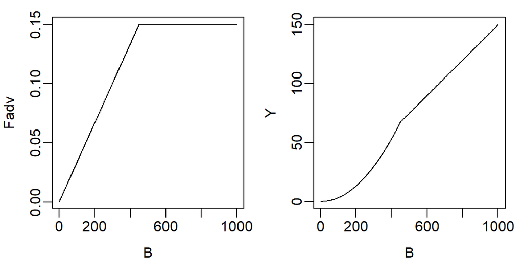

```r
res <- hcr(B=1:1000, Btrig = 450, Ftarg = 0.15)
op <- par(mfrow = c(1,2), mgp=c(2,0.5,0), mar = c(3,3,1,1))
plot(1:1000, res$Fadv, t="l", xlab = "B", ylab = "Fadv")
plot(1:1000, res$Y, t="l", xlab = "B", ylab = "Y")
```

```r
par(op)
```

### 6.1.3 MSE assumptions

Our imaginary population has the following growth parameters and HCR settings:

| Parameter | Description | Value |
| --- | --- | --- |
| `K` | Carrying capacity | 1000 |
| `r` | Growth rate | 0.2 |
| `a` | Allee effect | -1000 |
| `B1` | Starting population size | 1000 |
| `Btrig` | Biomass trigger to scale down fishing mortality | 450 |
| `Blim` | Biomass limit below which population is at risk | 350 |
| `Ftarg` | Target value for fishing mortality | 0.15 |

Using these settings, we can first run the MSE without uncertainty and growth variability to observe the behavior of the OM and MP:

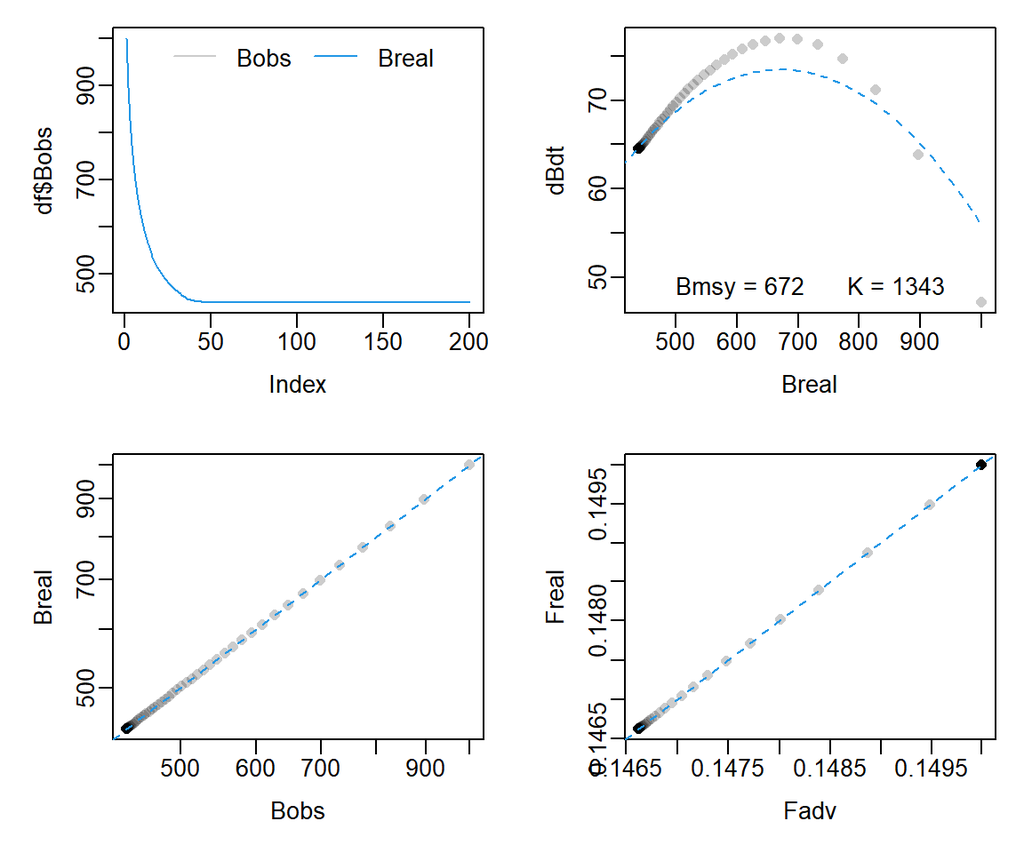

```r
# demo without error or variation
df <- mse(K = 1000, r = 0.2, a = -1000, nyear = 200,
  Btrig = 450, Ftarg = 0.15, B1 = 1000,
  assess_err = 0, imp_err = 0, r_var = 0, K_var = 0)
mseplot(df)
```

The observed and predicted biomass are equivalent (bottom-left panel), as is the advise fishing mortality (Fadv) versus the realized fishing mortality (bottom-right). The reference line in the top-right panel is just to show how the logistic growth with Allee effect OM differs from the standard logistic growth model. This discrepancy could be included in the MSE as model uncertainty, but is left out here.

The next run demonstrates the effect of including uncertainty:

| Parameter | Description | Value |
| --- | --- | --- |
| `assess_err` | Assessment error | 0.1 |
| `imp_err` | Implementation error | 0.05 |
| `r_var` | Variation in growth rate (CV) | 0.1 |
| `K_var` | Variation in carrying capacity (CV) | 0.05 |

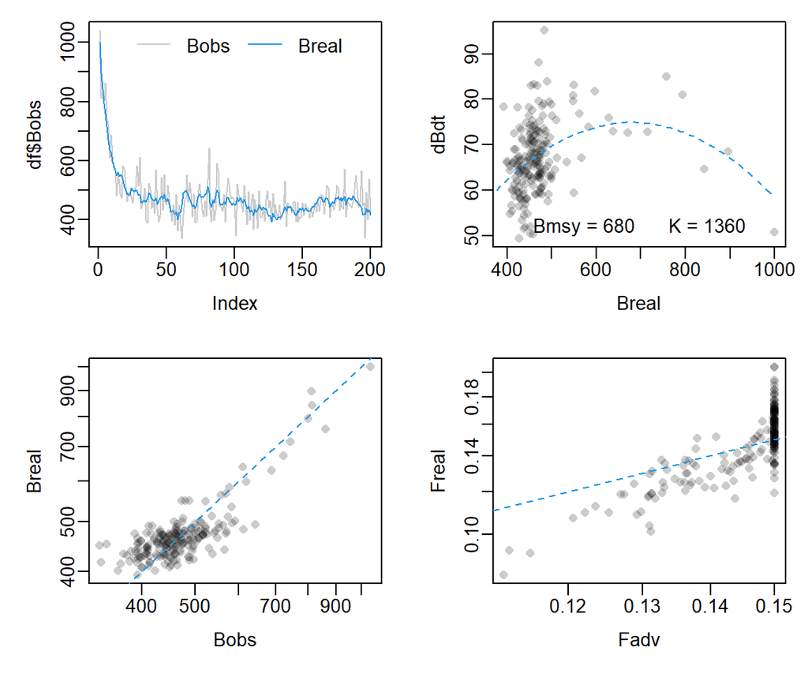

```r
# demo with error and variation
df <- mse(K = 1000, r = 0.2, a = -1000, nyear = 200,
  Btrig = 450, Ftarg = 0.15, B1 = 1000,
  assess_err = 0.1, imp_err = 0.05, r_var = 0.1, K_var = 0.05)
mseplot(df)
```

> **TASK:** Set up an loop to run the above MSE with uncertainty for 100 runs, and record the true biomass (`Breal`) from each run in a matrix (years (rows) by runs (cols)). Calculate the number of runs that dropped below the biomass threshold of 350 (i.e. `Blim`) during the last 20 years of the simulation.

> **TASK:** Try different combinations of `Btrig` and `Ftarg`. Record the probability of dropping below `Blim` and the mean yield. Try and identify the combination resulting in the highest mean yield while having a risk lower than 5%.

# 7 Metapopulation model

## 7.1 Metapopulation 1: occupancy model

The following is an example of an occupancy model for a metapopulation consisting of three populations. All populations are connected to each other and are either occupied or not. There is a baseline probability that a single population will go extinct (*P*) (i.e. local extinction). As long as there is one or more occupied populations in the metapopulation, unoccupied populations may be recolonized at a given probability (*R*). Finally, local extinction events can be correlated to each other (*C*), which will increase the probability of coinciding extinctions. The following function code will be used to simulate the described metapopulation, followed by several tasks to explore the influence of the model settings.

```r
metapop <- function(
  npop = 3, # Number of populations
  nyear = 500, # Number of years to simulate per run
  nrun = 1000, # Number of runs
  P = 0.0005, # Probability of annual extinction (Default: 0.0005)
  R = 0.001, # Probability of recolonization (Default: 0.001)
  C = 0.75, # Correlation of extinction probability (P) among populations
  plot = TRUE, # Plot output?
  progressBar = TRUE # Include progress bar?
){
  if(progressBar){ # setup progress bar
    pb = txtProgressBar(min = 0, max = nrun, style = 3)
  }
  N <- 0*seq(nyear)
  for(i in seq(nrun)){ # loop for runs
    ### create (correlated) extinctions
    # multivariate normal distributions by pop with correlation
    mu <- rep(0, npop)
    Sigma <- matrix(C, nrow = npop, ncol = npop)
    diag(Sigma) <- 1
    Ci <- MASS::mvrnorm(n = nyear, mu = mu, Sigma = Sigma)
    # convert to uniform distribution
    Ci <- pnorm(Ci)

    ### run model
    Ni = matrix(0, nrow = nyear, ncol = npop)
    Ni[1,] <- 1
    for(j in 2:nyear){ # loop for years
      # extinction
      Ni[j,] <- Ni[j-1,] * as.numeric(Ci[j,] > P)

      # recolonization
      if(sum(Ni[j,]) > 0){
        hit <- which(Ni[j,] == 0 & runif(npop) < R)
        Ni[j, hit] <- 1
      }
    }

    ### record total population
    Ni <- as.numeric(rowSums(Ni) > 0)
    N <- N + Ni

    if(progressBar) setTxtProgressBar(pb, i) # update progress bar
  }

  if(progressBar) close(pb) # close progress bar

  pExt <- 1 - N/nrun # probability of extinction by year
  dftmp <- data.frame(year = seq(nyear), pExt = pExt)
  if(plot){
    plot(dftmp, t = "l", ylab = "Extinction probability", xlab = "")
    legend("topleft", legend = paste0("Final prob = ",
      round(tail(dftmp$pExt, 1), 5)), bty = "n")
  }

  ### output
  return(dftmp)
}
```

> **TASK:** Using the 3-pop. metapopulation, explore how different levels of recolonization (`R`) affect the probability of extinction over a period of 500 years. Assume no extinction correlation (*i.e.* `C = 0`) and maintain the default annual extinction probability (`P = 0.0005`). *Hint: low recolonization rates may be needed to observe a significant number of extinctions (e.g. R < 2%). Increasing the number of runs will improve the robustness of the result, but at a computation cost.*

> **Extra TASK:** Try and create a single plot with the results from several recolonization settings. Add a labels or a legend to aid in the plot’s interpretation.

You should observe the probability of extinction increasing over time as additional metapopulations become extinct. Nevertheless, rates should be quite low given the rate of annual extinction. We will now focus on the cumulative extinction probability after 500 years. In addition to recolonization, will will now look at the importance of extinction correlations.

> **TASK:** Again, using the 3-pop. metapopulation, explore how different levels of recolonization (`R`) and extinction correlation (`0 < C < 1`) affect the probability of extinction over a period of 500 years. Keep track of the parameters used and their results for following group discussion (or plot on your own).

## 7.2 Metapopulation 2a: numbers based, single simulation

This following a generic example of a metapopulation consisting of 7 populations. The seven populations are located close to each other forming a compact system. Dispersal (in both directions) can occur between a population and its three nearest neighbors, except for the population in the middle, which exchanges migrants from all other populations (from Burgman, Ferson, and Akcakaya 1993).

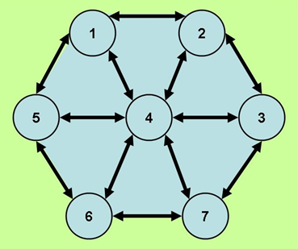

Spatial pattern of the example metapopulation

The following code will illustrate how the connectivity, distance, correlation and covariance matrices are constructed.

```r
require(MASS)
```

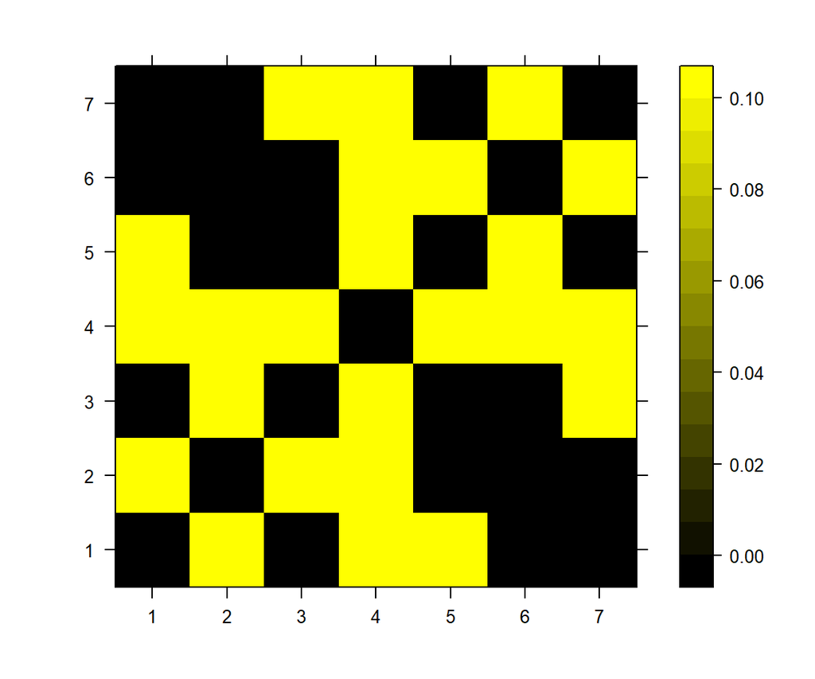

```r
require(lattice)

n_pops = 7
time = seq(100)
N = matrix(NA,length(time),n_pops)
N[1,] <- 10
lam <- c(0.9, 0.95, 1, 1.1, 1.1, 1.1, 1.05) #mean growth rates
cvar = 0.1        # coef. of variance (variance/mean) environmental variance on lam
lam_sd = cvar*lam   #standard deviation of lam
connectivity = 0.1

#dispersal matrix (connectivity) - may be a function of N
M=matrix(0, 7,7)
M[c(2,4,5,8,10,11,16,18,21,22,23,24,26,27,28,29,32,34,39,40,42,45,46,48)]<-connectivity
levelplot(M, ylab="", xlab="", col.regions=colorRampPalette(c("black", "yellow")))
```

```r
#distance matrix - for the calculation of correlation
coord <- data.frame(x=c(-1,1,2,0,-2,-1,1), y=c(1,1,0,0,0,-1,-1))
dist(t(coord))
```

```
##   x
## y 4
```

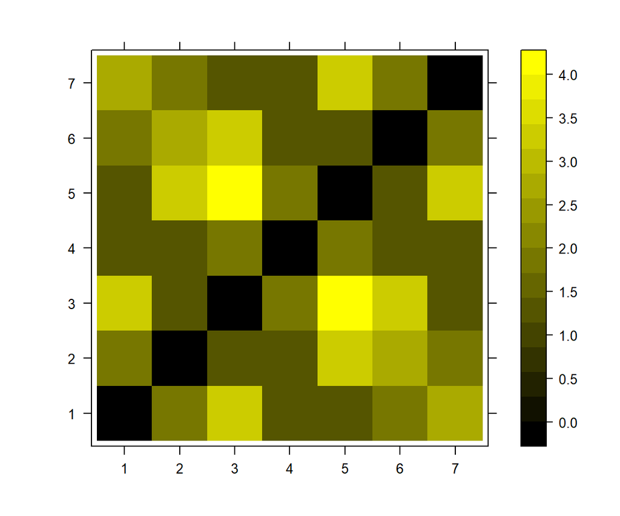

```r
D <- as.matrix(dist(coord))
levelplot(D, ylab="", xlab="", col.regions=colorRampPalette(c("black", "yellow")))
```

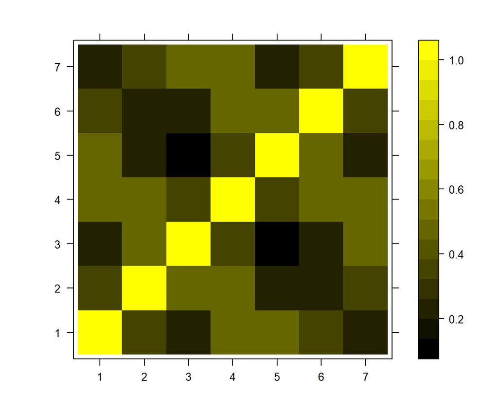

```r
#correlation matrix
R = 1*exp(-0.5*D)
levelplot(R, ylab="", xlab="", col.regions=colorRampPalette(c("black", "yellow")))
```

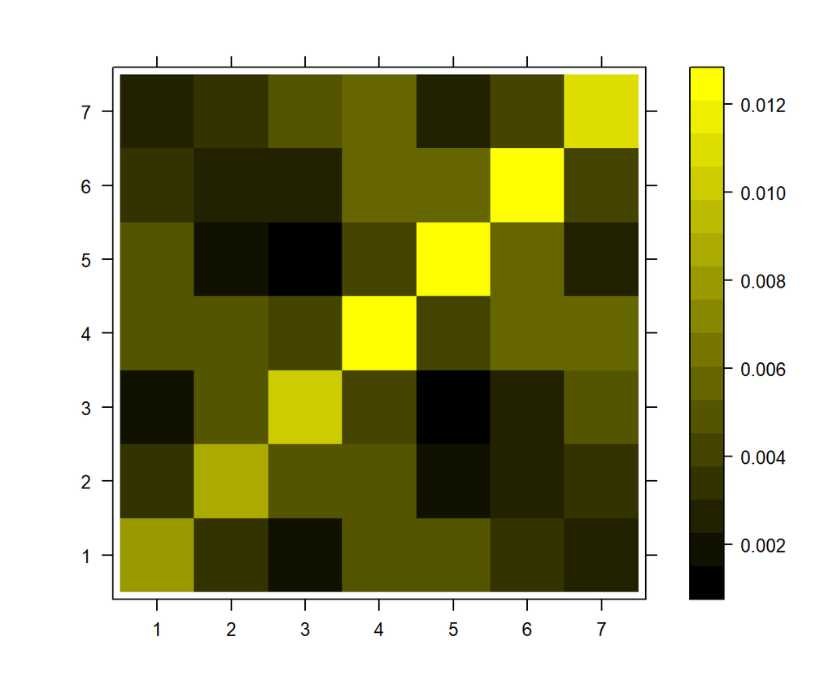

```r
#covariance matrix
P=lam_sd%*%t(lam_sd)*R
levelplot(P, ylab="", xlab="", col.regions=colorRampPalette(c("black", "yellow")))
```

```r
#calculate growth rate time series
C <- mvrnorm(n = length(time), lam, P)
dim(C)
```

```
## [1] 100   7
```

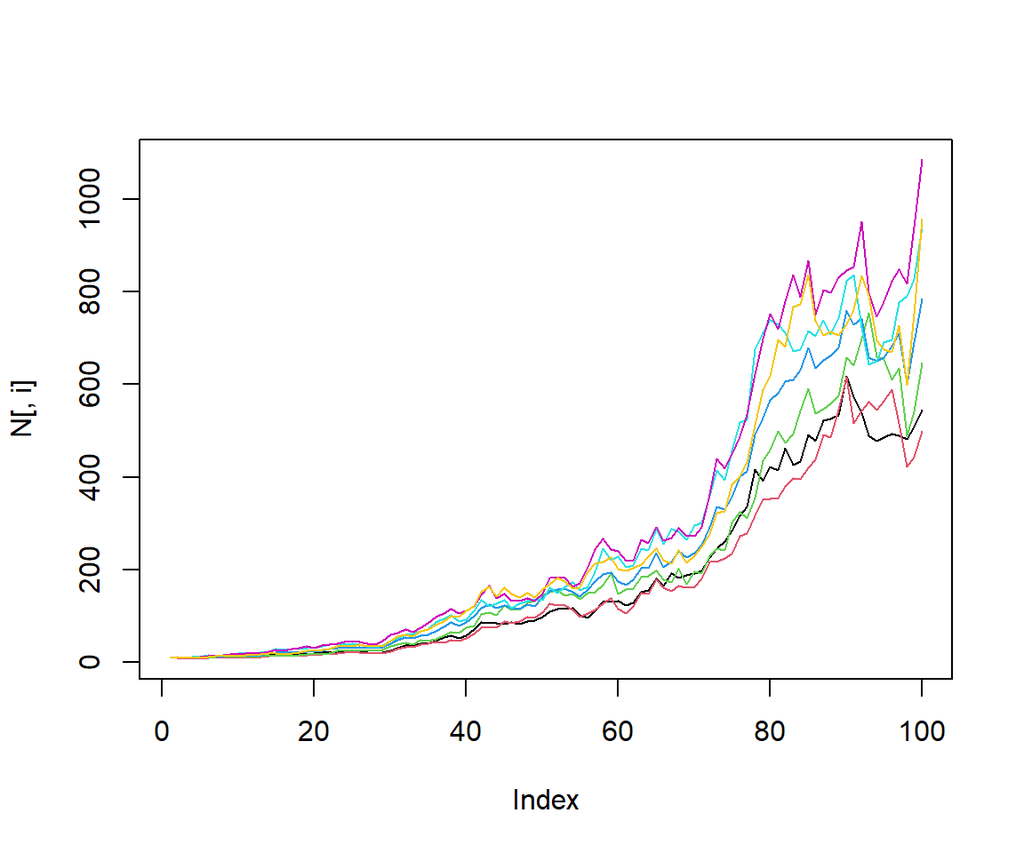

```r
for(i in 2:length(time)){
    lam.i <- C[i-1,]
    N[i,] <- lam.i * N[i-1,]
    E.i <- M * N[i,]
    N[i,] <- N[i,] + colSums(E.i) - rowSums(E.i)
}

#plot trajectories
for(i in 1:ncol(N)){
    if(i == 1){
        plot(N[,i], t="l", col=i, ylim=range(N))
    } else {
        lines(N[,i], col=i)
    }
}
```

## 7.3 Metapopulation 2b: multiple simulations

We can also perform several runs of the simulation and calculate the probability of quasi-extinction as was done in the Rhino example.

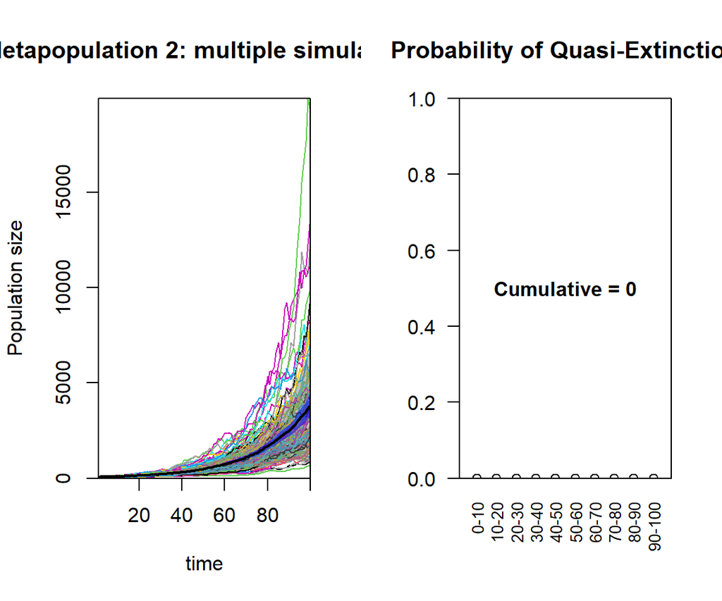

```r
title="Metapopulation 2: multiple simulations"
runs <- 100

Nmulti <- matrix(NA, length(time), runs)
for(j in 1:runs){
    N <- matrix(NA,length(time),n_pops)
    N[1,] <- 10
    C <- mvrnorm(n = length(time), lam, P)
    for(i in 2:length(time)){
        lam.i <- C[i-1,]
        N[i,] <- lam.i * N[i-1,]
        E.i <- M * N[i,]
        N[i,] <- N[i,] + colSums(E.i) - rowSums(E.i)
    }
    Nmulti[,j] <- rowSums(N)
}

pva.plot(Nmulti, quasi.ext=20, title=title)
```

# 8 Additional resources

- Homepage: http://www.r-project.org/
  - Documentation
  - R Journal
  - Search
  - FAQs
- Comprehensive R Archive Network (“CRAN”): http://cran.r-project.org/
  - Download
  - Packages
  - “Task views” – statistical subject area reviews (helps locate appropriate packages)
- Tutorials
  - Tutorial w/ examples: http://www.ats.ucla.edu/stat/r/
  - Tom Short’s reference card of coding commands: http://cran.r-project.org/doc/contrib/Short-refcard.pdf
  - Wikibooks – R Programming: http://en.wikibooks.org/wiki/R_Programming
- Statistics resources
  - Statistics: An Introduction Using R (Crawley ”Blue Book”) (Crawley 2007)
  - Stats with R: http://zoonek2.free.fr/UNIX/48_R/all.html
  - Quick-R http://www.statmethods.net/graphs/scatterplot.html
- Community
  - R-bloggers (This website offers articles about R aggregated from blogs): http://www.r-bloggers.com/
- Help!
  - Stack Overflow - Coding help: http://stackoverflow.com/questions/tagged/r
  - R Mailing Lists: http://www.r-project.org/mail.html
- Search
  - RSeek.org (an alternative search engine for R-related material): http://www.rseek.org/
  - R-help - Main R Mailing List: Primary help (e.g. searchable archives): https://stat.ethz.ch/mailman/listinfo/r-help
- Ecology resources
  - R for ecologists (MSU): http://ecology.msu.montana.edu/labdsv/R/labs
  - Ordination Methods for Ecologists (A nice overview of ordination): http://ordination.okstate.edu/
  - Fisheries-related analyses (e.g. packages `FSA`, `FLR`, `fishmethods`, `TropFishR`): http://derekogle.com/fishR/
- Other R resources collections: http://www.cerebralmastication.com/r-resources/

# References

Beverton, R. J. H., and S. J. Holt. 1957. “On the Dynamics of Exploited Fish Populations.” *Min Agric Fish and Food [Gt Brit] Fish Invest Ser Ii* 19: 5–533.

Burgman, Mark A., S. Ferson, and H. R. Akcakaya. 1993. *Risk Assessment in Conservation Biology*. 1st ed. Population and Community Biology Series 12. London ; New York: Chapman & Hall.

Conway, A. J., and P. S. Goodman. 1989. “Population Characteristics and Management of Black Rhinoceros Diceros Bicornis Minor and White Rhinoceros Ceratotherium Simum Simum in Ndumu Game Reserve, South Africa.” *Biological Conservation* 47 (2): 109–22. https://doi.org/10.1016/0006-3207(89)90094-3.

Crawley, Michael J. 2007. *The R Book*. Chichester, England ; Hoboken, N.J: Wiley.

Crouse, Deborah T., Larry B. Crowder, and Hal Caswell. 1987. “A Stage-Based Population Model for Loggerhead Sea Turtles and Implications for Conservation.” *Ecology* 68 (5): 1412–23. https://doi.org/10.2307/1939225.

Mace, Georgina M., and Russell Lande. 1991. “Assessing Extinction Threats: Toward a Reevaluation of IUCN Threatened Species Categories.” *Conservation Biology* 5 (2): 148–57. https://doi.org/10.1111/j.1523-1739.1991.tb00119.x.

Punt, André E, Doug S Butterworth, Carryn L de Moor, José A A De Oliveira, and Malcolm Haddon. 2016. “Management Strategy Evaluation: Best Practices.” *Fish and Fisheries* 17 (2): 303–34. https://doi.org/10.1111/faf.12104.

Wolff, M., M. H. Taylor, and G. Tesfaye. 2015. “Implications of Using Small Meshed Gillnets for the Sustainability of Fish Populations: A Theoretical Exploration Based on Three Case Studies.” *Fisheries Management and Ecology* 22 (5): 379–87. https://doi.org/10.1111/fme.12137.

[^1]: Thuenen Institute of Sea Fisheries, Bremerhaven, Germany